# Introduction to StatComp18054

By Zhiyuan Zhang

2019-01-11

## 2018-9-14

## Question

Implement at least three examples of different types in the book “R for Beginners”.

## Answer

Example 1

This is an example of matrix calculation in 3.5.8 of the book “R for Beginners”.

```r
m1<-matrix(1,nr=2,nc=2)
m2<-matrix(2,nr=2,nc=2)
# Merge vector or matrix
rbind(m1,m2)
```

```
##      [,1] [,2]
## [1,]    1    1
## [2,]    1    1
## [3,]    2    2
## [4,]    2    2
```

```r
cbind(m1,m2)
```

```
##      [,1] [,2] [,3] [,4]
## [1,]    1    1    2    2
## [2,]    1    1    2    2
```

```r
# Matrix product
rbind(m1,m2)%*%cbind(m1,m2)
```

```
##      [,1] [,2] [,3] [,4]
## [1,]    2    2    4    4
## [2,]    2    2    4    4
## [3,]    4    4    8    8
## [4,]    4    4    8    8
```

```r
cbind(m1,m2)%*%rbind(m1,m2)
```

```
##      [,1] [,2]
## [1,]   10   10
## [2,]   10   10
```

```r
# Diagonal operation and diagonal matrix
diag(m1)
```

```
## [1] 1 1
```

```r
diag(rbind(m1,m2)%*%cbind(m1,m2))
```

```
## [1] 2 2 8 8
```

```r
diag(m1)<-10
m1
```

```
##      [,1] [,2]
## [1,]   10    1
## [2,]    1   10
```

```r
diag(3)
```

```
##      [,1] [,2] [,3]
## [1,]    1    0    0
## [2,]    0    1    0
## [3,]    0    0    1
```

```r
v<-c(10,20,30)
diag(v)
```

```
##      [,1] [,2] [,3]
## [1,]   10    0    0
## [2,]    0   20    0
## [3,]    0    0   30
```

```r
diag(2.1,nr=3,nc=5)
```

```
##      [,1] [,2] [,3] [,4] [,5]
## [1,]  2.1  0.0  0.0    0    0
## [2,]  0.0  2.1  0.0    0    0
## [3,]  0.0  0.0  2.1    0    0
```

```r
# Inverse matrix
solve(diag(v))
```

```
##      [,1] [,2]       [,3]
## [1,]  0.1 0.00 0.00000000
## [2,]  0.0 0.05 0.00000000
## [3,]  0.0 0.00 0.03333333
```

```r
# Matrix QR decomposition
qr(diag(v))
```

```
## $qr
##      [,1] [,2] [,3]
## [1,]  -10    0    0
## [2,]    0  -20    0
## [3,]    0    0   30
##
## $rank
## [1] 3
##
## $qraux
## [1]  2  2 30
##
## $pivot
## [1] 1 2 3
##
## attr(,"class")
## [1] "qr"
```

```r
# Eigenvalue and eigenvector
eigen(diag(v))
```

```
## eigen() decomposition
## $values
## [1] 30 20 10
##
## $vectors
##      [,1] [,2] [,3]
## [1,]    0    0    1
## [2,]    0    1    0
## [3,]    1    0    0
```

```r
# Use table to output eigenvectors
knitr::kable(eigen(diag(v))$vectors,col.names=c("first eigenvector", "second eigenvector", "third eigenvector"), align = c('c','c','c'))
```

| first eigenvector | second eigenvector | third eigenvector |
| --- | --- | --- |
| 0 | 0 | 1 |
| 0 | 1 | 0 |
| 1 | 0 | 0 |

```r
# Singular value decomposition
svd(diag(v))
```

```
## $d
## [1] 30 20 10
##
## $u
##      [,1] [,2] [,3]
## [1,]    0    0    1
## [2,]    0    1    0
## [3,]    1    0    0
##
## $v
##      [,1] [,2] [,3]
## [1,]    0    0    1
## [2,]    0    1    0
## [3,]    1    0    0
```

Example 2

This is an example of function “layout” to split the current graphics window into multiple parts in 4.1.2 of the book “R for Beginners”.

```r
layout(matrix(1:4,2,2))
mat<-matrix(1:4,2,2)
mat
```

```
##      [,1] [,2]
## [1,]    1    3
## [2,]    2    4
```

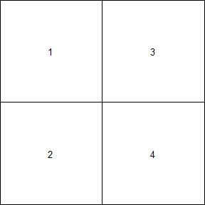

```r
layout(mat)
layout.show(4)
```

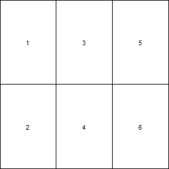

```r
layout(matrix(1:6,3,2))
layout.show(6)
layout(matrix(1:6,2,3))
layout.show(6)
```

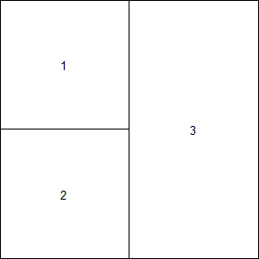

```r
m<-matrix(c(1:3,3),2,2)
layout(m)
layout.show(3)
```

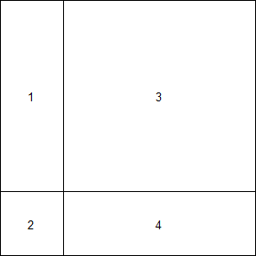

```r
m<-matrix(1:4,2,2)
layout(m,widths=c(1,3),heights=c(3,1))
layout.show(4)
```

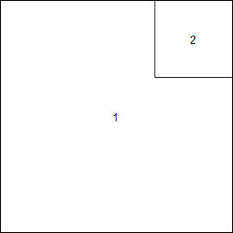

```r
m<-matrix(c(1,1,2,1),2,2)
layout(m,widths=c(2,1),heights=c(1,2))
layout.show(2)
```

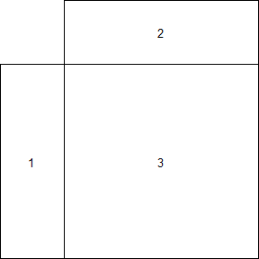

```r
m<-matrix(0:3,2,2)
layout(m,c(1,3),c(1,3))
layout.show(3)
```

## 2018-9-21

## Question 1

A discrete random variable X has probability mass function

| x | 0 | 1 | 2 | 3 | 4 |
| --- | --- | --- | --- | --- | --- |
| p(x) | 0.1 | 0.2 | 0.2 | 0.2 | 0.3 |

Use the inverse transform method to generate a random sample of size 1000 from the distribution of X. Construct a relative frequency table and compare the empirical with the theoretical probabilities. Repeat using the R sample function

## Answer

This is the inverse transform method to generate a random sample.

```r
x<-c(0:4)
p<-c(0.1,0.2,0.2,0.2,0.3)
cp<-cumsum(p)
m<-1000
#the random sample is in numeric r
r<-numeric(m)
r<-x[findInterval(runif(m),cp)+1]
#the sample frequency is in ct
ct<-as.vector(table(r))
result<-rbind(x,ct/sum(ct)/p)
rownames(result)<-c("x","relative frequency")
result
```

```
##                    [,1] [,2] [,3]  [,4]      [,5]
## x                  0.00 1.00 2.00 3.000 4.0000000
## relative frequency 0.99 0.97 1.03 1.025 0.9866667
```

This is to use the sample function to generate a random sample.

```r
x<-c(0:4)
p<-c(0.1,0.2,0.2,0.2,0.3)
#the random sample is in numeric r1
r1<-sample(x,size=1000,replace=TRUE,prob=p)
#the sample frequency is in ct1
ct1<-as.vector(table(r1))
result1<-rbind(x,ct1/sum(ct1)/p)
rownames(result1)<-c("x","relative frequency")
result1
```

```
##                    [,1] [,2]  [,3] [,4]      [,5]
## x                  0.00 1.00 2.000 3.00 4.0000000
## relative frequency 1.04 0.99 1.105 0.95 0.9566667
```

## Question 2

Write a function to generate a random sample of size n from the Beta(a, b) distribution by the acceptance-rejection method. Generate a random sample of size 1000 from the Beta(3,2) distribution. Graph the histogram of the sample with the theoretical Beta(3,2) density superimposed

## Answer

Beta(a, b) distribution with pdf:$f(x)=\frac{1}{B(a,b)}x^{a-1}(1-x)^{b-1}, 0<x<1$. Take pdf:$g(x)=1,0<x<1$. We take constant c bigger than the maximum of f(x), then $f(x)\leq cg(x)$ for all x.

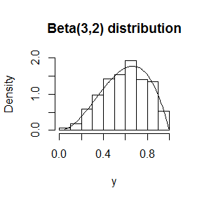

```r
randomBeta<-function(n,a,b){
m=(1-a)/(2-a-b)
max=m^(a-1)*((1-m)^(b-1))/beta(a,b)#maximum of f(x)
c<-max+3 #take c bigger than the maximum
j<-k<-0
y<-numeric(n)
while (k < n) {
u <- runif(1)
j <- j + 1
x <- runif(1) #random variate from g
rho<-x^(a-1)*((1-x)^(b-1))/beta(a,b)/c
if (rho> u) {
#accept x
k <- k + 1
y[k] <- x
}
}
return(list("random sample"=y,"times"=j,"c"=c))
}
result<-randomBeta(n=1000,a=3,b=2)
y<-result[[1]]
hist(y,probability = TRUE,main="Beta(3,2) distribution",ylim = c(0,2))
x<-seq(0,1,0.01)
lines(x,x^2*(1-x)/beta(3,2)) #pdf of Beta(3,2)
```

```r
times<-result[[2]] #times of acceptance-rejection
times
```

```
## [1] 4830
```

```r
c<-result[[3]] #constant c
c
```

```
## [1] 4.777778
```

## Answer

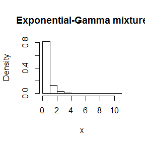

```r
n=1000
r=4
beta=2
lambda=rgamma(n,r,beta)
x=rexp(n,lambda)
hist(x,prob=TRUE,main="Exponential-Gamma mixture")
```

## 2018-9-28

## Question 1:

5.4 Write a function to compute a Monte Carlo estimate of the $Beta(3, 3)$ cdf, and use the function to estimate $F(x)$ for $x = 0.1, 0.2, . . ., 0.9$. Compare the estimates with the values returned by the pbeta function in R.

## Answer

The $Beta(3, 3)$ cdf:$F(x)=\int^{x}_{0}\frac{1}{B(a,b)}t^{a-1}(1-t)^{b-1}\,dt$. Use antithetic variables to compute a Monte Carlo estimate as follows: $g(U_i)=\frac{1}{B(a,b)}{U_i}^{a-1}(1-{U_i})^{b-1}x$, $\hat{\theta}=\frac{1}{m}\sum_{i=1}^{m/2}(g(U_i)+g(1-U_i))$.

```r
mypbeta<-function(a,b,x){ # antithetic variables to compute a Monte Carlo estimate of the Beta(3, 3) cdf
  m=1000000
  u=runif(m/2,min=0,max=x)
  u1=1-u
  g=1/beta(a,b)*u^(a-1)*(1-u)^(b-1)*x
  g1=1/beta(a,b)*u1^(a-1)*(1-u1)^(b-1)*x
  theta=(mean(g)+mean(g1))/2
  sd=sd(c(g,g1))/m
  return(list("theta"=theta,"sd"=sd))
}
x=seq(0.1,0.9,by=0.1)
MC=numeric(9)# Monte Carlo estimate
sd=numeric(9)
for(i in 1:9){
  result=mypbeta(3,3,x[i])
  MC[i]=result[[1]]
  sd[i]=result[[2]]
}
pBeta=pbeta(x,3,3)# the values returned by the pbeta function in R
cdf=rbind(MC,pBeta)
knitr::kable(cdf,col.names=x)
```

|  | 0.1 | 0.2 | 0.3 | 0.4 | 0.5 | 0.6 | 0.7 | 0.8 | 0.9 |
| --- | --- | --- | --- | --- | --- | --- | --- | --- | --- |
| MC | 0.0085631 | 0.0578784 | 0.1629639 | 0.3176655 | 0.5003429 | 0.682496 | 0.8374645 | 0.9431792 | 0.9910459 |
| pBeta | 0.0085600 | 0.0579200 | 0.1630800 | 0.3174400 | 0.5000000 | 0.682560 | 0.8369200 | 0.9420800 | 0.9914400 |

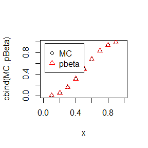

```r
matplot(x,cbind(MC,pBeta),col=1:2,pch=1:2,xlim=c(0,1))# Compare using figure
legend("topleft", inset=.05,legend=c("MC","pbeta"),col=1:2,pch=1:2)
```

## Question 2

5.9 The Rayleigh density $[156, (18.76)]$ is $f(x)=\frac{x}{\sigma^2}e^{-x^2/(2\sigma^2)},x\ge0,\sigma>0$. Implement a function to generate samples from a Rayleigh($\sigma$) distribution, using antithetic variables. What is the percent reduction in variance of $\frac{X+X'}{2}$ compared with $\frac{X_1+X_2}{2}$ for independent $X_1,X_2$?

## Answer

The cdf:$F(x)=1-e^{-\frac{x^2}{2\sigma^2}}$. It’s easy to generate samples using the inverse transform: $X=F^-(U)=\sqrt{-2\sigma^2\ln(1-U)},U\sim U(0,1)$.

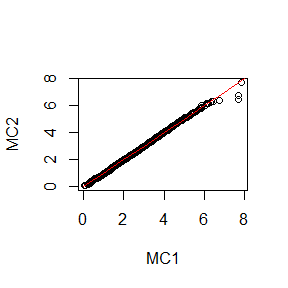

```r
myrRayleigh<-function(n,sigma,antithetic=TRUE){
  u=runif(n/2)
  if(!antithetic)
    {v=runif(n/2)}else
    {v=1-u}
  u=c(u,v)
  x=sqrt(-2*sigma^2*log(1-u))
  return(x)
}
n=1000
set.seed(123)
MC1=myrRayleigh(n,2,antithetic = TRUE)
set.seed(123)
MC2=myrRayleigh(n,2,antithetic = FALSE)
qqplot(MC1,MC2) #Compare the order statistics of the two groups of samples
y=seq(0,10)
lines(y,y,col=2)
```

```r
1-var(MC1)/var(MC2)#percent reduction in variance
```

```
## [1] 0.01562257
```

## Question 3

5.14 Obtain a Monte Carlo estimate of $\int_1^\infty\frac{x^2}{\sqrt{2\pi}} e^{-{x^2}/2}\,dx$ by importance sampling.

## Answer

Then, we define $f_2(x)=xe^{-\frac{x^2-1}{2}}$. Taking $Z=X^2-1$, then $f_2(z)=\frac{1}{2}e^{-\frac{z}{2}}$. Z is an exponential distribution.

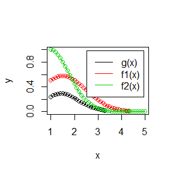

```r
x=seq(1,5,0.1)
g=function(x)x^2/sqrt(2*pi)*exp(-(x^2)/2)
f1=function(x)1/((1-pnorm(-0.5))*sqrt(2*pi))*exp(-((x-1.5)^2)/2)
f2=function(x)x*exp(-((x^2)-1)/2)
plot(x,g(x),col=1,type="o",ylim=c(0,1),lty=1,ylab="y")
points(x,f1(x),col=2,type="o",lty=1)
lines(x,f2(x),col=3,type="o",lty=1)
legend("topright",inset=.05,legend=c("g(x)","f1(x)","f2(x)"),lty=1,col=1:3,horiz=FALSE)
```

```r
n=1000
set.seed(123)
X=rnorm(1.5*n,mean=1.5,sd=1)
X=X[X>1]
X=X[1:n]
theta1=mean(g(X)/f1(X))
sd1=sd(g(X)/f1(X))/n
theta1
```

```
## [1] 0.40263
```

```r
sd1
```

```
## [1] 0.0001170964
```

```r
set.seed(123)
Z=rexp(n,rate=0.5)
Y=sqrt(Z+1)
theta2=mean(g(Y)/f2(Y))
sd2=sd(g(Y)/f2(Y))/n
theta2
```

```
## [1] 0.404797
```

```r
sd2
```

```
## [1] 0.0001237528
```

## 2018-10-12

## Question 1

6.9 Let X be a non-negative random variable with $\mu= E[X] < ∞$. For a random sample $x1, \dots, xn$ from the distribution of X, the Gini ratio is defined by $G=\frac{1}{2n^2\mu}\sum_{j=1}^n\sum_{i=1}^n|x_i-x_j|$. The Gini ratio is applied in economics to measure inequality in income distribution (see e.g. [163]). Note that G can be written in terms of the order statistics $x(i)$ as $G=\frac{1}{n^2\mu}\sum_{i=1}^n(2i-n-1)x(i)$ If the mean is unknown, let $\hat G$ be the statistic G with $\mu$ replaced by $\bar x$. Estimate by simulation the mean, median and deciles of $\hat G$ if X is standard lognormal. Repeat the procedure for the uniform distribution and Bernoulli(0.1). Also construct density histograms of the replicates in each case.

## Answer

```r
Giniratio=function(n,distribution){
  if(distribution=="lognormal") {
    x=exp(rnorm(n))
  }
  if(distribution=="uniform") {
    x=runif(n)
  }
  if(distribution=="Bernoulli") {
    x=rbinom(n,size=1000,0.1)
  }
  xorder=sort(x)
  G=0
  for(i in 1:n){
    G=(2*i-n-1)*xorder[i]
  }
  G=G/(n^2*mean(x))
  return(G)
}
n=1000
m=1000
Gini=matrix(0,nrow=m,ncol=3)
set.seed(123)
for(i in 1:m){
  Gini[i,1]=Giniratio(n=n,distribution="lognormal")
  Gini[i,2]=Giniratio(n=n,distribution="uniform")
  Gini[i,3]=Giniratio(n=n,distribution="Bernoulli")
}
colMeans(Gini)
```

```
## [1] 0.016453424 0.001996825 0.001318343
```

```r
decile=matrix(0,9,3)
med=numeric(3)
s=seq.int(0,m-1,by=m/10)[-1]
for(i in 1:3){
  decile[,i]=sort(Gini[,i])[s]
  med[i]=median(Gini[,i])
}
med
```

```
## [1] 0.014959948 0.001995718 0.001313210
```

```r
decile
```

```
##             [,1]        [,2]        [,3]
##  [1,] 0.01040535 0.001946957 0.001275480
##  [2,] 0.01166070 0.001967294 0.001287525
##  [3,] 0.01268030 0.001978103 0.001297416
##  [4,] 0.01381037 0.001987204 0.001305003
##  [5,] 0.01495962 0.001995666 0.001313178
##  [6,] 0.01616142 0.002004997 0.001324016
##  [7,] 0.01783330 0.002015924 0.001333911
##  [8,] 0.02006418 0.002026961 0.001345563
##  [9,] 0.02433156 0.002044281 0.001367144
```

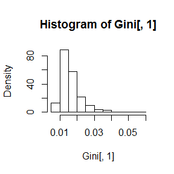

```r
hist(Gini[,1],freq=F)
```

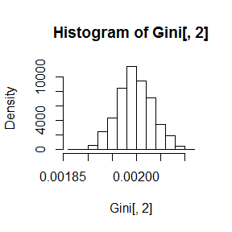

```r
hist(Gini[,2],freq=F)
```

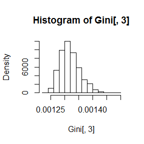

```r
hist(Gini[,3],freq=F)
```

## Question 2

6.10 Construct an approximate 95% confidence interval for the Gini ratio $\gamma=E[G]$ if $X$ is lognormal with unknown parameters. Assess the coverage rate of the estimation procedure with a Monte Carlo experiment

## Answer

```r
Giniratio=function(n,distribution){
  if(distribution=="lognormal") {
    x=exp(rnorm(n))
  }
  if(distribution=="uniform") {
    x=runif(n)
  }
  if(distribution=="Bernoulli") {
    x=rbinom(n,size=1000,0.1)
  }
  xorder=sort(x)
  G=0
  for(i in 1:n){
    G=(2*i-n-1)*xorder[i]
  }
  G=G/(n^2*mean(x))
  return(G)
}
n=1000
m=1000
Gini=numeric(m)
set.seed(123)
for(i in 1:m){
  Gini[i]=Giniratio(n=n,distribution="lognormal")
}
CI=c(mean(Gini)-qt(0.975,1e4-2)*sd(Gini),mean(Gini)+qt(0.975,1e4-2)*sd(Gini))
CI
```

```
## [1] 0.00277584 0.03015684
```

## Question 3

6.B Tests for association based on Pearson product moment correlation $\rho$, Spearman’s rank correlation coefficient $\rho_{s}$, or Kendall’s coefficient $\tau$, are implemented in cor.test. Show (empirically) that the nonparametric tests based on $\rho_{s}$ or $\tau$ are less powerful than the correlation test when the sampled distribution is bivariate normal. Find an example of an alternative (a bivariate distribution $(X,Y)$ such that $X$ and $Y$ are dependent) such that at least one of the nonparametric tests have better empirical power than the correlation test against this alternative.

## Answer

```r
library(mvtnorm)
test=function(method,r){
n=100
m=1000
mean=c(0,0)
sigma=matrix(c(1,r,r,1),nrow=2)
p=mean(replicate(m,expr={
x=rmvnorm(n,mean,sigma)
cor.test(x[,1],x[,2],method=method)$p.value<=0.05
}))
return(p)
}
test1=function(method){             ##(X,Y)~(X,v*X),  X~N(0,1),P(V=1)=P(V=-1)=0.5
n=100
m=1000
p=mean(replicate(m,expr={
x=rnorm(n)
a=rbinom(n,1,0.5)
v=2*a-1
y=data.frame(x=x,y=v*x)
cor.test(y[,1],y[,2],method="pearson")$p.value<=0.05
}))
return(p)
}
test("pearson",0.2)
```

```
## [1] 0.532
```

```r
test("kendall",0.2)
```

```
## [1] 0.458
```

```r
test("spearman",0.2)
```

```
## [1] 0.447
```

```r
test1("pearson")
```

```
## [1] 0.235
```

```r
test1("kendall")
```

```
## [1] 0.25
```

```r
test1("spearman")
```

```
## [1] 0.228
```

## 2018-11-2

## Question 1

7.1 Compute a jackknife estimate of the bias and the standard error of the correlation statistic in Example 7.2.

## Answer

```r
library(bootstrap) #for the law data
law
```

```
##    LSAT  GPA
## 1   576 3.39
## 2   635 3.30
## 3   558 2.81
## 4   578 3.03
## 5   666 3.44
## 6   580 3.07
## 7   555 3.00
## 8   661 3.43
## 9   651 3.36
## 10  605 3.13
## 11  653 3.12
## 12  575 2.74
## 13  545 2.76
## 14  572 2.88
## 15  594 2.96
```

```r
theta.hat=cor(law$LSAT, law$GPA)
theta.hat
```

```
## [1] 0.7763745
```

```r
n=nrow(law)
j.cor=function(x,i)cor(x[i,1],x[i,2])
theta.jack=numeric(n)
for(i in 1:n){
  theta.jack[i]=j.cor(law,(1:n)[-i])
}
bias.jack=(n-1)*(mean(theta.jack)-theta.hat)
bias.jack
```

```
## [1] -0.006473623
```

```r
se.jack=sd(theta.jack)*sqrt((n-1)^2/n)
se.jack
```

```
## [1] 0.1425186
```

## Question 2

7.5 Refer to Exercise 7.4. Compute 95% bootstrap confidence intervals for the mean time between failures $1/ \lambda$ by the standard normal, basic, percentile, and BCa methods. Compare the intervals and explain why they may differ.

## Answer

```r
library(boot)
aircondit
```

```
##    hours
## 1      3
## 2      5
## 3      7
## 4     18
## 5     43
## 6     85
## 7     91
## 8     98
## 9    100
## 10   130
## 11   230
## 12   487
```

```r
b.mean=function(x,i)mean(x[i])
mean.boot=boot(data=aircondit$hours,statistic=b.mean,R=1000)
mean.boot
```

```
##
## ORDINARY NONPARAMETRIC BOOTSTRAP
##
##
## Call:
## boot(data = aircondit$hours, statistic = b.mean, R = 1000)
##
##
## Bootstrap Statistics :
##     original  bias    std. error
## t1* 108.0833   -0.08    38.70203
```

```r
CI=boot.ci(mean.boot,type=c("norm","basic","perc","bca"))
CI
```

```
## BOOTSTRAP CONFIDENCE INTERVAL CALCULATIONS
## Based on 1000 bootstrap replicates
##
## CALL :
## boot.ci(boot.out = mean.boot, type = c("norm", "basic", "perc",
##     "bca"))
##
## Intervals :
## Level      Normal              Basic
## 95%   ( 32.3, 184.0 )   ( 19.3, 168.7 )
##
## Level     Percentile            BCa
## 95%   ( 47.4, 196.8 )   ( 57.7, 247.4 )
## Calculations and Intervals on Original Scale
## Some BCa intervals may be unstable
```

The CIs of mean time between failures $1/ \lambda$ from left to right are basic, standard normal, percentile and BCa methods. We can find the times between failures has a right-biased distribution. The quantiles are left compared to the normal distribution.

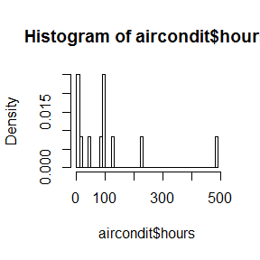

```r
hist(aircondit$hours,breaks = 50,freq = F)
```

## Question 3

7.8 Refer to Exercise 7.7. Obtain the jackknife estimates of bias and standard error of $\hat{\theta}$.

## Answer

The MLE of $\Sigma$ is sample covariance matrix $\Sigma_{sample}$ multiplied by $\frac{n-1}{n}$.

```r
library(bootstrap)
scor
```

```
##    mec vec alg ana sta
## 1   77  82  67  67  81
## 2   63  78  80  70  81
## 3   75  73  71  66  81
## 4   55  72  63  70  68
## 5   63  63  65  70  63
## 6   53  61  72  64  73
## 7   51  67  65  65  68
## 8   59  70  68  62  56
## 9   62  60  58  62  70
## 10  64  72  60  62  45
## 11  52  64  60  63  54
## 12  55  67  59  62  44
## 13  50  50  64  55  63
## 14  65  63  58  56  37
```

[output cut: 74 more lines]

```r
n=nrow(scor)
sigma.hat=cov(scor)*(n-1)/n
eigenvalues.hat=eigen(sigma.hat)$values
theta.hat=eigenvalues.hat[1]/sum(eigenvalues.hat)
theta.jack=numeric(n)
for(i in 1:n){
  sigma.jack=cov(scor[-i,])*(n-1)/n
  eigenvalues.jack=eigen(sigma.jack)$values
  theta.jack[i]=eigenvalues.jack[1]/sum(eigenvalues.jack)
}
bias.jack=(n-1)*(mean(theta.jack)-theta.hat)
bias.jack
```

```
## [1] 0.001069139
```

```r
se.jack=sd(theta.jack)*sqrt((n-1)^2/n)
se.jack
```

```
## [1] 0.04955231
```

## Question 4

7.11 In Example 7.18, leave-one-out (n-fold) cross validation was used to select the best fitting model. Use leave-two-out cross validation to compare the models.

## Answer

```r
library(DAAG)
```

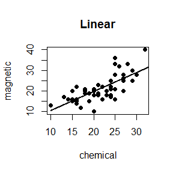

```r
attach(ironslag)
a <- seq(10, 40, .1) #sequence for plotting fits

L1 <- lm(magnetic ~ chemical)
plot(chemical, magnetic, main="Linear", pch=16)
yhat1 <- L1$coef[1] + L1$coef[2] * a
lines(a, yhat1, lwd=2)
```

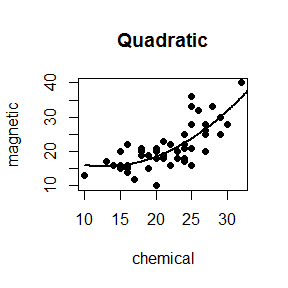

```r
L2 <- lm(magnetic ~ chemical + I(chemical^2))
plot(chemical, magnetic, main="Quadratic", pch=16)
yhat2 <- L2$coef[1] + L2$coef[2] * a + L2$coef[3] * a^2
lines(a, yhat2, lwd=2)
```

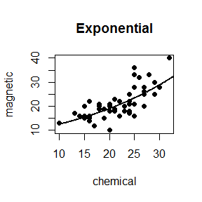

```r
L3 <- lm(log(magnetic) ~ chemical)
plot(chemical, magnetic, main="Exponential", pch=16)
logyhat3 <- L3$coef[1] + L3$coef[2] * a
yhat3 <- exp(logyhat3)
lines(a, yhat3, lwd=2)
```

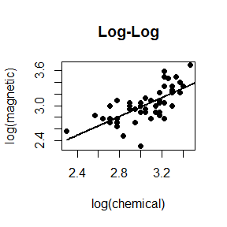

```r
L4 <- lm(log(magnetic) ~ log(chemical))
plot(log(chemical), log(magnetic), main="Log-Log", pch=16)
logyhat4 <- L4$coef[1] + L4$coef[2] * log(a)
lines(log(a), logyhat4, lwd=2)
```

```r
n <- length(magnetic) #in DAAG ironslag
e1 <- e2 <- e3 <- e4 <- numeric(n/2) #store the mean of squared residual for leave-two-out samples point
# for n/2-fold(leave-two-out) cross validation
# fit models on leave-two-out samples
for (k in 1:(n/2)) {
index<-c(2*k-1,2*k)  #Subscript of leave-two-out samples point
y <- magnetic[-index]
x <- chemical[-index]

J1 <- lm(y ~ x)
yhat1 <- J1$coef[1] + J1$coef[2] * chemical[index]
e1[k] <- mean((magnetic[index] - yhat1)^2)

J2 <- lm(y ~ x + I(x^2))
yhat2 <- J2$coef[1] + J2$coef[2] * chemical[index] +
J2$coef[3] * chemical[index]^2
e2[k] <- mean((magnetic[index] - yhat2)^2)

J3 <- lm(log(y) ~ x)
logyhat3 <- J3$coef[1] + J3$coef[2] * chemical[index]
yhat3 <- exp(logyhat3)
e3[k] <- mean((magnetic[index] - yhat3)^2)

J4 <- lm(log(y) ~ log(x))
logyhat4 <- J4$coef[1] + J4$coef[2] * log(chemical[index])
yhat4 <- exp(logyhat4)
e4[k] <- mean((magnetic[index] - yhat4)^2)
}
c(mean(e1), mean(e2), mean(e3), mean(e4))
```

```
## [1] 19.26253 17.35040 17.70556 19.81362
```

```r
L2
```

```
##
## Call:
## lm(formula = magnetic ~ chemical + I(chemical^2))
##
## Coefficients:
##   (Intercept)       chemical  I(chemical^2)
##      24.49262       -1.39334        0.05452
```

According to the prediction error criterion, Model 2, the quadratic model, would be the best fit for the data.

## 2018-11-16

Q1: 8.1 Implement the two-sample Cramer-von Mises test for equal distributions as a permutation test. Apply the test to the data in Examples 8.1 and 8.2.

A1:

```r
set.seed(123)
attach(chickwts)
x <- sort(as.vector(weight[feed == "soybean"]))
y <- sort(as.vector(weight[feed == "linseed"]))
detach(chickwts)
x
```

```
##  [1] 158 171 193 199 230 243 248 248 250 267 271 316 327 329
```

```r
y
```

```
##  [1] 141 148 169 181 203 213 229 244 257 260 271 309
```

```r
CMtest<-function(S1, S2){
  xS1=sort(S1)
  M=length(xS1)
  xS2=sort(S2)
  N=length(xS2)

  a=data.frame(val=xS1,rang=seq(M),ens=rep(1,M))
  b=data.frame(val=xS2,rang=seq(N),ens=rep(2,N))
  c=rbind(a,b)
  c=c[order(c$val),]
  c=data.frame(c,rangTot=seq(M+N))
  dtfM=c[which(c$ens==1),]
  dtfN=c[which(c$ens==2),]
  somN = sum( (dtfN$rang - dtfN$rangTot)**2 )
  somM = sum( (dtfM$rang - dtfM$rangTot)**2 )
  U = N*somN + M*somM
  CvM = (  (U / (N*M)) / (N+M) ) - ((4*M*N - 1)/(6*(M+N)))
  return(CvM)
}
R <- 999
z <- c(x, y)
K <- 1:length(z)
n<-length(x)
reps <- numeric(R)
t0 <- CMtest(x, y)
for (i in 1:R) {
  kn <- sample(K, size = n, replace = FALSE)
  x1 <- z[kn]
  y1 <- z[-kn]
  reps[i] <- CMtest(x1, y1)
}
p <- mean(abs(c(t0, reps)) >= abs(t0))
p
```

```
## [1] 0.429
```

The p-value does not support the alternative hypothesis that distributions differ.

Q2: Design experiments for evaluating the performance of the NN, energy, and ball methods in various situations 1 Unequal variances and equal expectations 2 Unequal variances and unequal expectations 3 Non-normal distributions: t distribution with 1 df (heavy-tailed distribution), bimodel distribution (mixture of two normal distributions) 4 Unbalanced samples (say, 1 case versus 10 controls) 5 Note: The parameters should be chosen such that the powers are distinguishable (say, range from 0.3 to 0.8).

A2:

```r
# library(RANN)
# library(boot)
# library(energy)
# library(Ball)
#
# m <- 1e3; k<-3; p<-2; mu <- 0.5; su <- 0.75; set.seed(12)
# n1 <- n2 <- 50; R<-999; n <- n1+n2; N = c(n1,n2)
# n3 <- 10; n4 <-100  #Unbalanced samples
#
# Tn <- function(z, ix, sizes,k) {
#    n1 <- sizes[1]; n2 <- sizes[2]; n <- n1 + n2
#    if(is.vector(z)) z <- data.frame(z,0);
#    z <- z[ix, ];
#    NN <- nn2(data=z, k=k+1) # what's the first column?
#    block1 <- NN$nn.idx[1:n1,-1]
#    block2 <- NN$nn.idx[(n1+1):n,-1]
#    i1 <- sum(block1 < n1 + .5); i2 <- sum(block2 > n1+.5)
#    (i1 + i2) / (k * n)
# }
#
# eqdist.nn <- function(z,sizes,k){
#   boot.obj <- boot(data=z,statistic=Tn,R=R,
#   sim = "permutation", sizes = sizes,k=k)
#   ts <- c(boot.obj$t0,boot.obj$t)
#   p.value <- mean(ts>=ts[1])
#   list(statistic=ts[1],p.value=p.value)
# }
```

```r
#Unequal variances and equal expectations
# p.values1 <- matrix(NA,m,3)
# for(i in 1:m){
#   x <- matrix(rnorm(n1*p),ncol=p);
#   y <- cbind(rnorm(n2),rnorm(n2,sd=su));
#   z <- rbind(x,y)
#   p.values1[i,1] <- eqdist.nn(z,N,k)$p.value
#   p.values1[i,2] <- eqdist.etest(z,sizes=N,R=R)$p.value
#   p.values1[i,3] <- bd.test(x=x,y=y,R=999,seed=i*12)$p.value
# }
```

```r
# #Unequal variances and unequal expectations
# p.values2 <- matrix(NA,m,3)
# for(i in 1:m){
#   x <- matrix(rnorm(n1*p),ncol=p);
#   y <- cbind(rnorm(n2),rnorm(n2,mean=mu,sd=su));
#   z <- rbind(x,y)
#   p.values2[i,1] <- eqdist.nn(z,N,k)$p.value
#   p.values2[i,2] <- eqdist.etest(z,sizes=N,R=R)$p.value
#   p.values2[i,3] <- bd.test(x=x,y=y,R=999,seed=i*12)$p.value
# }
```

```r
# #t distribution with 1 df (heavy-tailed distribution)
# p.values3 <- matrix(NA,m,3)
# for(i in 1:m){
#   x <- matrix(rt(n1*p,df=1),ncol=p);
#   y <- cbind(rt(n2,df=1),rt(n2,df=1));
#   z <- rbind(x,y)
#   p.values3[i,1] <- eqdist.nn(z,N,k)$p.value
#   p.values3[i,2] <- eqdist.etest(z,sizes=N,R=R)$p.value
#   p.values3[i,3] <- bd.test(x=x,y=y,R=999,seed=i*12)$p.value
# }
```

```r
# #Unbalanced samples (say, 1 case versus 10 controls)
# p.values4 <- matrix(NA,m,3)
# for(i in 1:m){
#   x <- matrix(rnorm(n3*p),ncol=p);
#   y <- cbind(rnorm(n4),rnorm(n4,mean = mu));
#   z <- rbind(x,y)
#   p.values4[i,1] <- eqdist.nn(z,N,k)$p.value
#   p.values4[i,2] <- eqdist.etest(z,sizes=c(n3,n4),R=R)$p.value
#   p.values4[i,3] <- bd.test(x=x,y=y,R=999,seed=i*12)$p.value
# }
# alpha <- 0.1;
# pow1 <- colMeans(p.values1<alpha)
# pow2 <- colMeans(p.values2<alpha)
# pow3 <- colMeans(p.values3<alpha)
# pow4 <- colMeans(p.values4<alpha)
# pow1
# pow2
# pow3
# pow4
```

Q3: 9.3 Use the Metropolis-Hastings sampler to generate random variables from a standard Cauchy distribution. Discard the first 1000 of the chain, and compare the deciles of the generated observations with the deciles of the standard Cauchy distribution (see qcauchy or qt with df=1). Recall that a Cauchy($\theta, \eta$) distribution has density function
$$f(x)=\frac{1}{\theta\pi(1+((x-\eta)/\theta)^2)} ,-\infty<x<\infty, \theta>0$$
The standard Cauchy has the Cauchy($\theta = 1, \eta = 0$) density. (Note that the standard Cauchy density is equal to the Student t density with one degree of freedom.)

A3: Using random walk Metropolis method, proposal distribution $g(|X)$ is $N(X,\sigma^2)$. We can generate random variables from a standard Cauchy distribution($t_1$ distribution) as follows:

```r
set.seed(1)
rw.Metropolis <- function(n, sigma, x0, N) {
        x <- numeric(N)
        x[1] <- x0
        u <- runif(N)
        k <- 0
        for (i in 2:N) {
            y <- rnorm(1, x[i-1], sigma)
                if (u[i] <= (dt(y, n) / dt(x[i-1], n)))
                x[i] <- y  else {
                    x[i] <- x[i-1]
                    k <- k + 1
                }
            }
        return(list(x=x, k=k))
        }

    n <- 1  #degrees of freedom for target Student t dist.
    N <- 5000
    sigma <- c(.05, .5, 2,  16)

    x0 <- 25
    rw1 <- rw.Metropolis(n, sigma[1], x0, N)
    rw2 <- rw.Metropolis(n, sigma[2], x0, N)
    rw3 <- rw.Metropolis(n, sigma[3], x0, N)
    rw4 <- rw.Metropolis(n, sigma[4], x0, N)

    #number of candidate points rejected
    print(c(rw1$k, rw2$k, rw3$k, rw4$k))
```

```
## [1]    2  570 1850 4008
```

```r
    # par(mfrow=c(2,2))
     refline <- qt(c(.025, .975), df=n)
    rw <- cbind(rw1$x, rw2$x, rw3$x,  rw4$x)
    # for (j in 1:4) {
    #     plot(rw[,j], type="l",
    #          xlab=bquote(sigma == .(round(sigma[j],3))),
    #          ylab="X", ylim=range(rw[,j]))
    #     abline(h=refline)
    # }
    # par(mfrow=c(1,1)) #reset to default

    Nd=1000  #number of discarded sample
    a <- c(.05, seq(.1, .9, .1), .95)
    Q <- qt(a, n)
    mc <- rw[(Nd+1):N, ]
    Qrw <- apply(mc, 2, function(x) quantile(x, a))
    knitr::kable(cbind(Q, Qrw),col.names=c("True","sigma=0.05","sigma=0.5","sigma=2","sigma=16"))
```

[output not shown]

Q4: 9.6 Rao [220, Sec. 5g] presented an example on genetic linkage of 197 animals in four categories (also discussed in [67, 106, 171, 266]). The group sizes are (125, 18, 20, 34). Assume that the probabilities of the corresponding multinomial distribution are
$$(\frac{1}{2}+\frac{\theta}{4},\frac{1-\theta}{4},\frac{1-\theta}{4},\frac{\theta}{4})$$
Estimate the posterior distribution of $\theta$ given the observed sample, using one of the methods in this chapter.

A4: The multinomial joint distribution of $X1, \cdots, X4$ has the probability vector
$$p=(\frac{1}{2}+\frac{\theta}{4},\frac{1-\theta}{4},\frac{1-\theta}{4},\frac{\theta}{4})$$
. The posterior distribution of $\theta$ given $(x1,\cdots, x4)=(125, 18, 20, 34)$ is therefore
$$p(\theta|(x1,\cdots, x4))= \frac{197!}{x1!x2!x3!x4!}p_1^{x1}p_2^{x2}p_3^{x3}p_4^{x4}$$
. Notice that $0<\theta<1$. The proposal distribution is uniform distribution.

```r
set.seed(12)
Gelman.Rubin <- function(psi) {
        # psi[i,j] is the statistic psi(X[i,1:j])
        # for chain in i-th row of X
        psi <- as.matrix(psi)
        n <- ncol(psi)
        k <- nrow(psi)

        psi.means <- rowMeans(psi)     #row means
        B <- n * var(psi.means)        #between variance est.
        psi.w <- apply(psi, 1, "var")  #within variances
        W <- mean(psi.w)               #within est.
        v.hat <- W*(n-1)/n + (B/n)     #upper variance est.
        r.hat <- v.hat / W             #G-R statistic
        return(r.hat)
}

size<-c(125,18,20,34)
prob <- function(y, size) {
        # computes (without the constant) the target density
        if (y < 0 || y >= 1)
            return (0)
        return((1/2+y/4)^size[1] *((1-y)/4)^size[2] * ((1-y)/4)^size[3] *(y/4)^size[4])
}

thetachain<-function(m){ #generate a Metropolis chain for theta
w<-0.5
u <- runif(m)  #for accept/reject step
v<-runif(m,-w,w) #proposal distribution
x<-rep(0,m)
x[1] <- 0.5
for (i in 2:m) {
    y <- x[i-1]+v[i]
    if (u[i] <= prob(y, size) / prob(x[i-1], size))
        x[i] <- y  else
   x[i] <- x[i-1]
}
return(x)
}
#generate the chains
k=4      #number of chains to generate
n=15000  #length of chains
b=1000   #burn-in length
theta <- matrix(0, nrow=k, ncol=n)
for (i in 1:k)
  theta[i, ] <- thetachain(m=n)
#compute diagnostic statistics
psi <- t(apply(theta, 1, cumsum))
for (i in 1:nrow(psi))
  psi[i,] <- psi[i,] / (1:ncol(psi))
print(Gelman.Rubin(psi))
```

```
## [1] 1.05677
```

```r
#plot psi for the four chains
#par(mfrow=c(2,2))
#for (i in 1:k)
#plot(psi[i, (b+1):n], type="l",xlab=i, ylab=bquote(psi))
#par(mfrow=c(1,1)) #restore default
#the sequence of R-hat statistics
rhat <- rep(0, n)
for (j in (b+1):n)
rhat[j] <- Gelman.Rubin(psi[,1:j])
#plot(rhat[(b+1):n], type="l", xlab="", ylab="R")
#abline(h=1.2, lty=2)
```

The chain has approximately converged to the target distribution within approximately 2000 iterations.

```r
#par(mfrow=c(2,2))
for (i in 1:k)
#hist(psi[i, 2001:n],xlab=i,freq=FALSE)
#par(mfrow=c(1,1)) #restore default
theta=rowMeans(psi[,2001:n])
#estimation of theta
mean(theta)
```

```
## [1] 0.6233276
```

## 2018-11-23

Q1: 9.6 Rao [220, Sec. 5g] presented an example on genetic linkage of 197 animals in four categories (also discussed in [67, 106, 171, 266]). The group sizes are (125, 18, 20, 34). Assume that the probabilities of the corresponding multinomial distribution are
$$(\frac{1}{2}+\frac{\theta}{4},\frac{1-\theta}{4},\frac{1-\theta}{4},\frac{\theta}{4})$$
Estimate the posterior distribution of $\theta$ given the observed sample, using one of the methods in this chapter. For exercise 9.6, use the Gelman-Rubin method to monitor convergence of the chain, and run the chain until it converges approximately to the target distribution according to $\hat{R}<1.2$.

A1: The multinomial joint distribution of $X1, \cdots, X4$ has the probability vector
$$p=(\frac{1}{2}+\frac{\theta}{4},\frac{1-\theta}{4},\frac{1-\theta}{4},\frac{\theta}{4})$$
. The posterior distribution of $\theta$ given $(x1,\cdots, x4)=(125, 18, 20, 34)$ is therefore
$$p(\theta|(x1,\cdots, x4))= \frac{197!}{x1!x2!x3!x4!}p_1^{x1}p_2^{x2}p_3^{x3}p_4^{x4}$$
. Notice that $0<\theta<1$. The proposal distribution is uniform distribution.

```r
set.seed(12)
Gelman.Rubin <- function(psi) {
        # psi[i,j] is the statistic psi(X[i,1:j])
        # for chain in i-th row of X
        psi <- as.matrix(psi)
        n <- ncol(psi)
        k <- nrow(psi)

        psi.means <- rowMeans(psi)     #row means
        B <- n * var(psi.means)        #between variance est.
        psi.w <- apply(psi, 1, "var")  #within variances
        W <- mean(psi.w)               #within est.
        v.hat <- W*(n-1)/n + (B/n)     #upper variance est.
        r.hat <- v.hat / W             #G-R statistic
        return(r.hat)
}

size<-c(125,18,20,34)
prob <- function(y, size) {
        # computes (without the constant) the target density
        if (y < 0 || y >= 1)
            return (0)
        return((1/2+y/4)^size[1] *((1-y)/4)^size[2] * ((1-y)/4)^size[3] *(y/4)^size[4])
}

thetachain<-function(m,x0){ #generate a Metropolis chain for theta
u <- runif(m)  #for accept/reject step
x<-rep(0,m)
x[1] <- x0
for (i in 2:m) {
    y <- runif(1)
    if (u[i] <= prob(y, size) / prob(x[i-1], size))
        x[i] <- y  else
   x[i] <- x[i-1]
}
return(x)
}
#generate the chains
k=4      #number of chains to generate
n=15000  #length of chains
b=1000   #burn-in length
x0=c(0.3,0.4,0.5,0.6)
theta <- matrix(0, nrow=k, ncol=n)
for (i in 1:k)
  theta[i, ] <- thetachain(m=n,x0=x0[i])
#compute diagnostic statistics
psi <- t(apply(theta, 1, cumsum))
for (i in 1:nrow(psi))
  psi[i,] <- psi[i,] / (1:ncol(psi))
print(Gelman.Rubin(psi))
```

```
## [1] 1.124801
```

```r
#plot psi for the four chains
#par(mfrow=c(2,2))
#for (i in 1:k)
#plot(psi[i, (b+1):n], type="l",xlab=i, ylab=bquote(psi))
#par(mfrow=c(1,1)) #restore default
#the sequence of R-hat statistics
rhat <- rep(0, n)
for (j in (b+1):n)
rhat[j] <- Gelman.Rubin(psi[,1:j])
#plot(rhat[(b+1):n], type="l", xlab="", ylab="R")
#abline(h=1.2, lty=2)
```

It seems the chain has approximately converged to the target distribution since $n=8000$.

```r
nc=8000
thetahat=mean(rowMeans(psi[,nc:n]))
thetahat
```

```
## [1] 0.6243849
```

Q2: 11.4 Find the intersection points A(k) in $(0, \sqrt{k})$ of the curves
$$S_{k-1}(a)=p \left( t(k-1)>\sqrt{\frac{a^2(k-1)}{k-a^2}} \right)$$
and
$$S_{k}(a)=p \left( t(k)>\sqrt{\frac{a^2k}{k+1-a^2}} \right)$$
for $k = 4:25, 100, 500, 1000$, where t(k) is a Student t random variable with k degrees of freedom. (These intersection points determine the critical values for a t-test for scale-mixture errors proposed by Szekely [260].)

A2: The problem becomes solving $f(a)=S_{k-1}(a)-S_{k}(a)=0$, given k.

```r
mys<-function(a,k){
    M=sqrt(a^2*k/(k+1-a^2))
    return(pt(M,df=k,lower.tail = FALSE))
}
myf<-function(a,k){
 mys(a=a,k=(k-1))-mys(a=a,k=k)
}
kc=c(4:25,100,500,1000)
A=rep(0,length(kc))
for(i in 1:length(kc)){
  A[i]=uniroot(myf,c(0.5,sqrt(kc[i]-1)),k=kc[i])$root
}
cbind(kc,A)
```

```
##         kc         A
##  [1,]    4  1.492119
##  [2,]    5  1.533558
##  [3,]    6  1.562757
##  [4,]    7  1.584430
##  [5,]    8  1.601180
##  [6,]    9  1.614519
##  [7,]   10  1.625384
##  [8,]   11  1.634381
##  [9,]   12  1.642026
## [10,]   13  1.648547
## [11,]   14  1.654150
## [12,]   15  1.659097
## [13,]   16  1.663432
## [14,]   17  1.667283
## [15,]   18  1.670724
## [16,]   19  1.673817
## [17,]   20  1.676614
## [18,]   21  1.679154
## [19,]   22  1.681442
## [20,]   23  1.683575
## [21,]   24  1.685536
## [22,]   25  1.687343
## [23,]  100  1.720599
## [24,]  500 22.338308
## [25,] 1000 31.606961
```

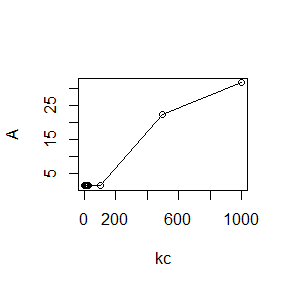

```r
plot(kc,A,type="o")
```

## 2018-11-30

## Q1:

11.6 Write a function to compute the cdf of the Cauchy distribution, which has density
$$\frac{1}{\pi\theta(1+[(x-\eta)/\theta]^2)},-\infty<x<\infty,$$
where $\theta > 0$. Compare your results to the results from the R function pcauchy. (Also see the source code in pcauchy.c.)

# A1:

```r
cauchy<-function(x,eta,theta){
   1/(theta*pi*(1+((x-eta)/theta)^2))
}
mypcauchy<-function(x,eta,theta){
  integrate(cauchy,lower=-Inf,upper=x,eta=eta,theta=theta)
}
x=seq(-2,2,by=0.5)
eta=1
theta=2
mycdf=rep(0,length(x))
for(i in 1:length(x)){
  mycdf[i]=mypcauchy(x[i],eta = eta,theta=theta)$value
}
Rcdf=pcauchy(x,location = eta,scale=theta)
cbind(x,mycdf,Rcdf)
```

```
##          x     mycdf      Rcdf
##  [1,] -2.0 0.1871670 0.1871670
##  [2,] -1.5 0.2147767 0.2147767
##  [3,] -1.0 0.2500000 0.2500000
##  [4,] -0.5 0.2951672 0.2951672
##  [5,]  0.0 0.3524164 0.3524164
##  [6,]  0.5 0.4220209 0.4220209
##  [7,]  1.0 0.5000000 0.5000000
##  [8,]  1.5 0.5779791 0.5779791
##  [9,]  2.0 0.6475836 0.6475836
```

## Q2:

A-B-O blood type problem

1. Let the three alleles be A, B, and O
2. Observed data: $nA· = nAA + nAO = 28 (A-type),$ $nB· = nBB + nBO = 24 (B-type),$ $nOO = 41 (O-type),$ $nAB = 70 (AB-type).$
3. Use EM algorithm to solve MLE of p and q (consider missing data nAA and nBB).
4. Record the maximum likelihood values in M-steps, are they increasing?

# A2:

E-step:
$$nAA0=E_{p_0,q_0}[nAA|nA.]=nA.\frac{p_0^2}{P_0^2+2p_0(1-p_0-q_0)}$$
$$nBB0=E_{p_0,q_0}[nBB|nB.]=nB.\frac{q_0^2}{q_0^2+2q_0(1-p_0-q_0)}$$
M-step:
$$L(p,q)=(p^2)^{nAA}(q^2)^{nBB}(r^2)^{nOO}(2pr)^{nAO}(2qr)^{nBO}(2pq)^{nAB}$$
Get MLE of p,q as new p0,q0 in E-step. Repeat this process until convergence. We can get MLE of p,q as follows

```r
nA=28
nB=24
nOO=41
nAB=70
l<-function(theta,nAA,nBB){
  p=theta[1]
  q=theta[2]
  r=1-p-q
  return(-(2*nAA*log(p)+2*nBB*log(q)+(nA-nAA)*log(2*p*r)+(nB-nBB)*log(2*q*r)+nAB*log(2*p*q)+2*nOO*log(r)))
  }
MLE<-function(p0,q0){
  r0=1-p0-q0
  nAA0=nA*p0^2/(p0^2+2*p0*r0)
  nBB0=nB*q0^2/(q0^2+2*q0*r0)
  return(optim(c(p0,q0),l,lower=c(0.01,0.01),upper=c(0.49,0.49),method = "L-BFGS-B",nAA=nAA0,nBB=nBB0)$par)
}
EM<-function(p0,q0,l,maxiter){
  theta0=c(p0,q0)
  theta=MLE(p0,q0)
  record=rbind(theta0,theta)
  iter=1
  while((max(abs(theta-c(p0,q0)))>l)&(iter<=maxiter)){
    p0=theta[1]
    q0=theta[2]
    theta=MLE(p0,q0)
    record=rbind(record,theta)
    iter=iter+1
  }
  return(list(record=record,iter=iter))
}
result=EM(0.4,0.2,0.000001,1000)
result #the first column records MLE of p, the second column records MLE of q
```

```
## $record
##             [,1]      [,2]
## theta0 0.4000000 0.2000000
## theta  0.3292434 0.3030677
## theta  0.3271758 0.3098293
## theta  0.3272959 0.3103645
## theta  0.3273387 0.3104164
## theta  0.3273446 0.3104242
## theta  0.3273452 0.3104259
## theta  0.3273444 0.3104268
##
## $iter
## [1] 7
```

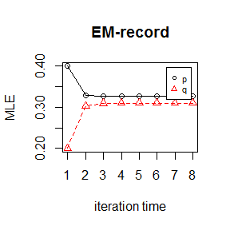

```r
matplot(result$record,type="o",pch=1:2,col=1:2,xlab="iteration time",ylab="MLE",main="EM-record")
legend("topright",inset=.05,legend=c("p","q"),
       pch=1:2,col=1:2,horiz=FALSE,cex=0.7)
```

We can find p converges to 0.32, q converges to 0.31 almost.

## 2018-12-7

Q1: 3.Use both for loops and lapply() to fit linear models to the mtcars using the formulas stored in this list

A1：

```r
set.seed(12)
attach(mtcars)
formulas <- list(
mpg ~ disp,
mpg ~ I(1 / disp),
mpg ~ disp + wt,
mpg ~ I(1 / disp) + wt
)
result1=lapply(formulas,lm)
result1
```

```
## [[1]]
##
## Call:
## FUN(formula = X[[i]])
##
## Coefficients:
## (Intercept)         disp
##    29.59985     -0.04122
##
##
## [[2]]
##
## Call:
## FUN(formula = X[[i]])
##
## Coefficients:
## (Intercept)    I(1/disp)
##       10.75      1557.67
##
##
## [[3]]
##
## Call:
## FUN(formula = X[[i]])
##
## Coefficients:
## (Intercept)         disp           wt
##    34.96055     -0.01772     -3.35083
##
##
## [[4]]
##
## Call:
## FUN(formula = X[[i]])
##
## Coefficients:
## (Intercept)    I(1/disp)           wt
##      19.024     1142.560       -1.798
```

```r
result2=result1
for(i in 1:4){
  result2[[i]]<-lm(formulas[[i]])
}
result2
```

```
## [[1]]
##
## Call:
## lm(formula = formulas[[i]])
##
## Coefficients:
## (Intercept)         disp
##    29.59985     -0.04122
##
##
## [[2]]
##
## Call:
## lm(formula = formulas[[i]])
##
## Coefficients:
## (Intercept)    I(1/disp)
##       10.75      1557.67
##
##
## [[3]]
##
## Call:
## lm(formula = formulas[[i]])
##
## Coefficients:
## (Intercept)         disp           wt
##    34.96055     -0.01772     -3.35083
##
##
## [[4]]
##
## Call:
## lm(formula = formulas[[i]])
##
## Coefficients:
## (Intercept)    I(1/disp)           wt
##      19.024     1142.560       -1.798
```

Q2: 4.Fit the model mpg ~ disp to each of the bootstrap replicates of mtcars in the list below by using a for loop and lapply().Can you do it without an anonymous function?

A2:

```r
bootstraps <- lapply(1:10, function(i) {rows <- sample(1:nrow(mtcars), rep = TRUE)
mtcars[rows, ]})
result3=lapply(bootstraps,function(a){lm(a$mpg~a$disp)})
result3
```

```
## [[1]]
##
## Call:
## lm(formula = a$mpg ~ a$disp)
##
## Coefficients:
## (Intercept)       a$disp
##    29.09282     -0.04032
##
##
## [[2]]
##
## Call:
## lm(formula = a$mpg ~ a$disp)
##
## Coefficients:
## (Intercept)       a$disp
##    30.69042     -0.04482
##
##
## [[3]]
##
## Call:
## lm(formula = a$mpg ~ a$disp)
##
## Coefficients:
## (Intercept)       a$disp
##    29.64310     -0.04024
##
##
## [[4]]
##
## Call:
## lm(formula = a$mpg ~ a$disp)
##
## Coefficients:
## (Intercept)       a$disp
##    29.38534     -0.03999
##
##
```

[output cut: 43 more lines]

```
## lm(formula = a$mpg ~ a$disp)
##
## Coefficients:
## (Intercept)       a$disp
##    29.97662     -0.04217
##
##
## [[10]]
##
## Call:
## lm(formula = a$mpg ~ a$disp)
##
## Coefficients:
## (Intercept)       a$disp
##    29.79607     -0.04326
```

```r
result4=result3
for(i in 1:10){
  result4[[i]]=lm(bootstraps[[i]]$mpg~bootstraps[[i]]$disp)
}
result4
```

```
## [[1]]
##
## Call:
## lm(formula = bootstraps[[i]]$mpg ~ bootstraps[[i]]$disp)
##
## Coefficients:
##          (Intercept)  bootstraps[[i]]$disp
##             29.09282              -0.04032
##
##
## [[2]]
##
## Call:
## lm(formula = bootstraps[[i]]$mpg ~ bootstraps[[i]]$disp)
##
## Coefficients:
##          (Intercept)  bootstraps[[i]]$disp
##             30.69042              -0.04482
##
##
## [[3]]
##
## Call:
## lm(formula = bootstraps[[i]]$mpg ~ bootstraps[[i]]$disp)
##
## Coefficients:
##          (Intercept)  bootstraps[[i]]$disp
##             29.64310              -0.04024
##
##
## [[4]]
##
## Call:
## lm(formula = bootstraps[[i]]$mpg ~ bootstraps[[i]]$disp)
##
## Coefficients:
##          (Intercept)  bootstraps[[i]]$disp
##             29.38534              -0.03999
##
##
```

[output cut: 43 more lines]

```
## lm(formula = bootstraps[[i]]$mpg ~ bootstraps[[i]]$disp)
##
## Coefficients:
##          (Intercept)  bootstraps[[i]]$disp
##             29.97662              -0.04217
##
##
## [[10]]
##
## Call:
## lm(formula = bootstraps[[i]]$mpg ~ bootstraps[[i]]$disp)
##
## Coefficients:
##          (Intercept)  bootstraps[[i]]$disp
##             29.79607              -0.04326
```

Q3: 5.For each model in the previous two exercises, extract R2 using the function below.

A3:

```r
rsq <- function(mod) summary(mod)$r.squared
lapply(result1,rsq)
```

```
## [[1]]
## [1] 0.7183433
##
## [[2]]
## [1] 0.8596865
##
## [[3]]
## [1] 0.7809306
##
## [[4]]
## [1] 0.8838038
```

```r
lapply(result2,rsq)
```

```
## [[1]]
## [1] 0.7183433
##
## [[2]]
## [1] 0.8596865
##
## [[3]]
## [1] 0.7809306
##
## [[4]]
## [1] 0.8838038
```

```r
lapply(result3,rsq)
```

```
## [[1]]
## [1] 0.8630147
##
## [[2]]
## [1] 0.6953983
##
## [[3]]
## [1] 0.6290129
##
## [[4]]
## [1] 0.7225284
##
## [[5]]
## [1] 0.7934105
##
## [[6]]
## [1] 0.6705007
##
## [[7]]
## [1] 0.654581
##
## [[8]]
## [1] 0.6283484
##
## [[9]]
## [1] 0.704806
##
## [[10]]
## [1] 0.6420804
```

```r
lapply(result4,rsq)
```

```
## [[1]]
## [1] 0.8630147
##
## [[2]]
## [1] 0.6953983
##
## [[3]]
## [1] 0.6290129
##
## [[4]]
## [1] 0.7225284
##
## [[5]]
## [1] 0.7934105
##
## [[6]]
## [1] 0.6705007
##
## [[7]]
## [1] 0.654581
##
## [[8]]
## [1] 0.6283484
##
## [[9]]
## [1] 0.704806
##
## [[10]]
## [1] 0.6420804
```

Q4: 3.The following code simulates the performance of a t-test for non-normal data. Use sapply() and an anonymous function to extract the p-value from every trial.

A4:

```r
set.seed(12)
trials <- replicate(
  100,
  t.test(rpois(10, 10), rpois(7, 10)),
  simplify = FALSE
)
sapply(1:100, function(i){trials[[i]]$p.value})
```

```
##   [1] 0.082499937 0.330784795 0.993047864 0.477290348 0.406404458
##   [6] 0.085187996 0.844111822 0.379938241 0.635628066 0.786437709
##  [11] 0.526876535 0.715040454 0.110824795 0.809350882 0.065930332
##  [16] 0.808664441 0.859265752 0.608593210 0.651687787 0.793923636
##  [21] 0.387259211 0.012011087 0.304023541 0.229197439 0.765511648
##  [26] 0.231204886 0.898434865 0.308273827 0.098051642 0.064364010
##  [31] 0.772742843 0.961870044 0.126951686 0.678720694 0.149908710
##  [36] 0.027666868 0.673732195 0.276325272 0.525299726 0.935774019
##  [41] 0.577354583 0.550658883 0.523809077 0.821460941 0.798589758
##  [46] 0.521098617 0.896046097 0.286044180 0.195748512 0.431651130
##  [51] 0.754932607 0.588776309 0.547781320 0.417193253 0.452785842
##  [56] 0.013746851 0.638739685 0.745462528 0.882385322 0.089179648
##  [61] 0.003132675 0.442411777 0.703167263 0.482340507 0.498785819
##  [66] 0.925679134 0.932265499 0.016249868 0.759802613 0.226230558
##  [71] 0.944056294 0.273858627 0.453569026 0.245504470 0.634473466
##  [76] 0.780832008 0.650077794 0.248769279 0.279270617 0.949787094
##  [81] 0.824539608 0.333125010 0.612011717 0.268620544 0.283314643
##  [86] 0.419813050 0.017097642 0.641691213 0.221103687 0.200611697
##  [91] 0.647253469 0.550783330 0.147248867 0.748154631 0.377174096
##  [96] 0.849968120 0.759417068 0.900474893 0.582294493 0.615195429
```

Q5: Implement a combination of Map() and vapply() to create an lapply() variant that iterates in parallel over all of its inputs and stores its outputs in a vector (or a matrix). What arguments should the function take?

A5:

```r
library(foreach)
library(datasets)

formulas <- list(
   mtcars$mpg ~ mtcars$disp,
   mtcars$mpg ~ I(1 / mtcars$disp),
   mtcars$mpg ~ mtcars$disp + mtcars$wt,
   mtcars$mpg ~ I(1 / mtcars$disp) + mtcars$wt
)

foreach(i=1:4) %do%
  lm(formulas[[i]])
```

```
## [[1]]
##
## Call:
## lm(formula = formulas[[i]])
##
## Coefficients:
## (Intercept)  mtcars$disp
##    29.59985     -0.04122
##
##
## [[2]]
##
## Call:
## lm(formula = formulas[[i]])
##
## Coefficients:
##      (Intercept)  I(1/mtcars$disp)
##            10.75           1557.67
##
##
## [[3]]
##
## Call:
## lm(formula = formulas[[i]])
##
## Coefficients:
## (Intercept)  mtcars$disp    mtcars$wt
##    34.96055     -0.01772     -3.35083
##
##
## [[4]]
##
## Call:
## lm(formula = formulas[[i]])
##
## Coefficients:
##      (Intercept)  I(1/mtcars$disp)         mtcars$wt
##           19.024          1142.560            -1.798
```

## 2018-12-14

Q1: 4. Make a faster version of chisq.test() that only computes the chi-square test statistic when the input is two numeric vectors with no missing values. You can try simplifying chisq.test() or by coding from the mathematical definition (http://en.wikipedia.org/wiki/Pearson%27s_chi-squared_test).

A1:

```r
set.seed(12)
x=sample(c(1,2,3),1000,prob =c(0.2,0.5,0.3) ,replace = TRUE)
y=sample(c(4,5,6),1000,prob =c(0.4,0.4,0.2) ,replace = TRUE)
my_chisqtest<-function(x,y){
  A=table(x,y)
  n=nrow(A)
  p=ncol(A)
  N=sum(A)
  rowp=rowSums(A)/N
  colp=colSums(A)/N
  E=N*rowp%*%t(colp)
  chisq=sum((A-E)^2/E)
  return(chisq)
}
library(microbenchmark)
microbenchmark(chisq.test(x,y),times=1000)
```

```
## Unit: milliseconds
##              expr      min       lq     mean   median       uq      max
##  chisq.test(x, y) 2.317121 2.401695 2.804839 2.533069 2.886344 8.689616
##  neval
##   1000
```

```r
microbenchmark(my_chisqtest(x,y),times=1000)
```

```
## Unit: milliseconds
##                expr      min       lq     mean   median       uq     max
##  my_chisqtest(x, y) 2.151672 2.162757 2.267195 2.197858 2.239118 11.9592
##  neval
##   1000
```

```r
chisq.test(x,y)
```

```
##
##  Pearson's Chi-squared test
##
## data:  x and y
## X-squared = 3.9856, df = 4, p-value = 0.408
```

```r
my_chisqtest(x,y)
```

```
## [1] 3.985577
```

Q2: 5. Can you make a faster version of table() for the case of an input of two integer vectors with no missing values? Can you use it to speed up your chi-square test?

A2:

```r
my_table1<-function(x,y){
  x=factor(x)
  y=factor(y)
  xl=levels(x)
  yl=levels(y)
  n=length(x)
  nxl=length(xl)
  nyl=length(yl)
  table=matrix(0,nxl,nyl,dimnames = list(xl,yl))
  for(i in 1:n){
    for(j in 1:nxl){
      for(k in 1:nyl){
        if(x[i]==xl[j]&y[i]==yl[k])
          table[j,k]=table[j,k]+1
      }
    }
  }
  return(table)
}
library(microbenchmark)
microbenchmark(my_table1(x,y),times=10)
```

```
## Unit: milliseconds
##             expr      min       lq     mean   median       uq      max
##  my_table1(x, y) 412.7588 413.4161 425.4648 416.2386 421.1499 472.2469
##  neval
##     10
```

```r
microbenchmark(table(x,y),times=10)
```

```
## Unit: milliseconds
##         expr      min       lq     mean   median       uq      max neval
##  table(x, y) 2.094195 2.094606 2.160704 2.126834 2.178767 2.438233    10
```

```r
my_table1(x,y)
```

```
##     4   5  6
## 1  69  79 40
## 2 214 205 87
## 3 137 120 49
```

```r
table(x,y)
```

```
##    y
## x     4   5   6
##   1  69  79  40
##   2 214 205  87
##   3 137 120  49
```

```r
my_table2<-function(x,y){
  x=factor(x)
  y=factor(y)
  xl=levels(x)
  yl=levels(y)
  n=length(x)
  nxl=length(xl)
  nyl=length(yl)
  table=matrix(0,nxl,nyl,dimnames = list(xl,yl))
  for(i in 1:nxl){
    xi=factor(x,levels=xl[i])
    I=which(!is.na(xi))
    table[i,]=tabulate(y[I])
  }
  return(table)
}
library(microbenchmark)
microbenchmark(my_table2(x,y),times=10)
```

```
## Unit: milliseconds
##             expr      min       lq     mean   median       uq     max
##  my_table2(x, y) 2.205863 2.241171 3.578278 2.289614 2.347502 14.6647
##  neval
##     10
```

```r
microbenchmark(table(x,y),times=10)
```

```
## Unit: milliseconds
##         expr      min       lq     mean   median       uq      max neval
##  table(x, y) 2.101995 2.106102 2.230209 2.123959 2.207506 2.880801    10
```

```r
my_table2(x,y)
```

```
##     4   5  6
## 1  69  79 40
## 2 214 205 87
## 3 137 120 49
```

```r
table(x,y)
```

```
##    y
## x     4   5   6
##   1  69  79  40
##   2 214 205  87
##   3 137 120  49
```

The function my_table1() using multiple loops is slower.And the function my_table2() is almost as fast as table().

```r
my_chisqtest1<-function(x,y){
  A=my_table2(x,y)
  n=nrow(A)
  p=ncol(A)
  N=sum(A)
  rowp=rowSums(A)/N
  colp=colSums(A)/N
  E=N*rowp%*%t(colp)
  chisq=sum((A-E)^2/E)
  return(chisq)
}
library(microbenchmark)
microbenchmark(chisq.test(x,y),times=1000)
```

```
## Unit: milliseconds
##              expr     min       lq     mean   median       uq      max
##  chisq.test(x, y) 2.32369 2.401694 2.796874 2.471281 2.775497 84.94319
##  neval
##   1000
```

```r
microbenchmark(my_chisqtest1(x,y),times=1000)
```

```
## Unit: milliseconds
##                 expr      min       lq     mean   median       uq    max
##  my_chisqtest1(x, y) 2.231318 2.249792 2.507237 2.315274 2.428174 13.018
##  neval
##   1000
```

```r
chisq.test(x,y)
```

```
##
##  Pearson's Chi-squared test
##
## data:  x and y
## X-squared = 3.9856, df = 4, p-value = 0.408
```

```r
my_chisqtest1(x,y)
```

```
## [1] 3.985577
```